# NextGen Hydrofabric

What is it and how do we get there?

Mike Johnson[^1]

[figure not shown]

# hyAggregate

The goal of `hyAggregate` is to develop *aggregated* hydrologic and hydraulic networks to inform modeling tasks reliant on uniform length (flowpath) and area (catchment) distributions.

## Installation

Building a nextgen ready hydrofabric only requires one package that can be installed from Github with:

```r
remotes::install_github("mikejohnson51/hyAggregate")
```

# What is a hydrofabric?

The first question generally raised is, “what is a”hydrofabric”? To date, the term has been nebulous at best and has been used to describe data as narrow as a set of cartographic lines and network connectivity, all the way to encompass the entire spatial data architectures needed to map and model the flow of water and flood extents.

Here, a “Nextgen Hydrofabric” will include the following four parts:

1. The blue line **features** (flowpaths) and per-flowline catchments **features**
2. flowline/catchment **topologies**
3. **Attributes** to support routing and runoff modeling
4. The **software** and **data models** to make the creation of these open, reproducible, and flexible.

In this breakdown, features *define* the computational elements for hydrology and hydraulic modeling; topologies *link* data together for space/time processing (modular elements that act as a whole); attributes *provide* the information for model execution (physics based, conceptual and ML/AI model formulations); and software and data models *develop* community standards, reproducibility, and flexibility to support analysis at scale.

## Motivation

`hyAggregate` is part of a larger family of projects and packages aiming to support federal (USGS/NOAA) water modeling efforts. The whole suite of development tools can be installed with:

```r
remotes::install_github("NOAA-OWP/hydrofabric")
```

Attaching this library, simular to the `tidyverse`, installs and loads a canon of software designed to manipulate, modify, describe, process, and quantify hydrologic networks and land surface attributes:

```r
library(hydrofabric)
```

| Repo | Purpose |
| --- | --- |
| USGS-R/nhdplusTools | Tools for for network manipulation |
| dblodgett-usgs/hyRefactor | Tools for network refactoring |
| mikejohnson51/hyAggregate | Tools for distribution based network aggregation and ngen file creation |
| mikejohnson51/opendap.catalog | Tools for for accessing remote data resources for parameter and attributes estimation |
| mikejohnson51/zonal | Tools for rapid catchment parameter summarization |
| JamesColl-NOAA/eHydRo | Tools for accessing Army Corp bathymetry data and embedding it in a DEM/extracting cross sections |

## A National Reference Fabric

`hyAggregate` relies on data products generated as part of the [Geospatial Fabric for National Hydrologic Modeling, version 2.0](https://www.sciencebase.gov/catalog/item/60be0e53d34e86b93891012b) project, the general outline of which, can be seen below:

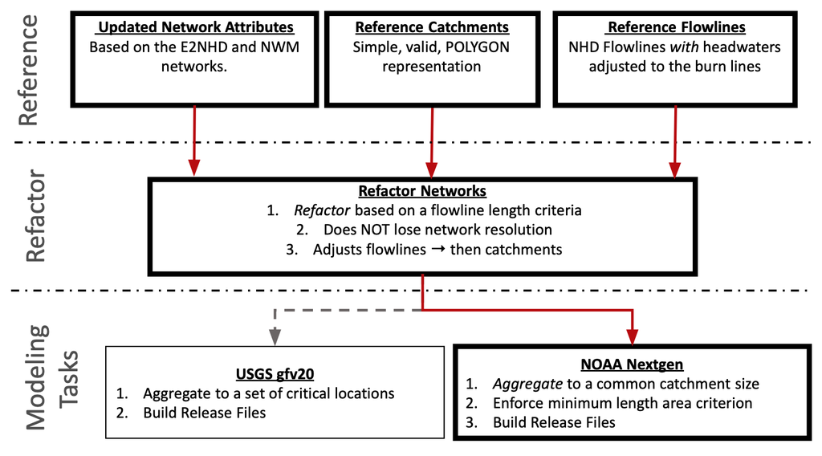

Figure 1

In the first row of Figure 1, there are three (3) **reference** products.

1. An updated *network attributes* table that provides attributes for the network features in the data model of NHDPlusV2, but with substantial improvements based on contributions from the USGS, NOAA OWP, NCAR and others.
2. A set of *reference catchment* geometries in which geometric errors and artifacts in the NHDPlus CatchmentSP layer are corrected/removed.
3. A set of *reference flowline* geometries where headwater flowlines have been replaced with the NHDPlus Burn lines

The CONUS reference files for these datasets can be downloaded here respectively ([attributes](https://www.sciencebase.gov/catalog/item/60c92503d34e86b9389df1c9), [catchments](https://www.sciencebase.gov/catalog/file/get/61295190d34e40dd9c06bcd7?f=__disk__8b%2F4d%2Fe8%2F8b4de8b52d2d0b24a4b0ea40f17e6cd7cbb0a504), [flowpaths](https://sciencebase.usgs.gov/manager/item/61295190d34e40dd9c06bcd7/file/cl39kyiq2007y0vo1fdke9stf))

## A National Refactored Fabric

In the second row of Figure 1, the reference products are **refactored** based on a minimum flowpath criterion. This process is facilitated by the [`hyRefactor`](https://github.com/dblodgett-usgs/hyRefactor)[^2] R package. The concept of refactoring includes (1) Splitting large or long catchments in the reference data to create a more uniform catchment size distribution and (2) collapsing catchment topology by removing very small inter confluence, merge very small headwaters. The goal of refactoring is to **NOT** reduce the fidelity of the network, but instead to move the network to a more uniform/coherent version of the network.

Refactoring is a parameter-based workflow, the selection of these parameters *does* impact the resulting network, for the National Scale fabric

| Parameter | Purpose | Elected Value |
| --- | --- | --- |
| split_flines_meters | the maximum length flowpath desired in the output. | 10,000 |
| collapse_flines_meters | the minimum length of inter-confluence flowpath desired in the output. | 1,000 |
| collapse_flines_main_meters | the minimum length of between-confluence flowpaths. | 1,000 |

The refactored output is shared under the Refactored Parent item of the above ScienceBase resource (available [here](https://www.sciencebase.gov/catalog/item/61fbfdced34e622189cb1b0a))

There is a difference between the use of **flowline** and **flowpath**. Per the [hy_features standard](https://docs.opengeospatial.org/is/14-111r6/14-111r6.html), a catchment can have one primary [flowpath](https://docs.opengeospatial.org/is/14-111r6/14-111r6.html#_flowpath_also_flow_path) (1:1) but multiple [flowlines](https://docs.opengeospatial.org/is/14-111r6/14-111r6.html#_flow_line_also_flowline) (1:many).

There is also a difference in the concept of a catchment, which is the holistic unit of hydrology, and a [catchment divide](https://docs.opengeospatial.org/is/14-111r6/14-111r6.html#_catchment_divide) which is the edge bounded by an inflown and outflow node

For the development of the reference fabric and modeling task outputs, we seek to define a set of divides and corresponding flowpaths from the reference flowlines and cathcments. :::

## Getting Reference & Refactored Data

All reference, refactored and ngen hydrofabric archives live on ScienceBase. They can be accessed with the web interface or can be downlaoded programatically.

The `hyAggregate::get_reference_fabric()` utility will download the most current geofabric for a Vector Processing Unit (VPU). Options include downloading the “refactored” (deafult) or “reference” data. If the requested file already exists the file path will be returned. Here we can find the local path to the reference fabric for VPU=01 in the `./data` directory, and explore the layers contained within:

```r
VPU = "01"
file = get_reference_fabric(VPU = VPU, dir = "data")
st_layers(file)
```

```
#> Driver: GPKG
#> Available layers:
#>       layer_name     geometry_type features fields
#> 1     final_POIS             Point     3185     11
#> 2   nhd_flowline       Line String    65600     36
#> 3  nhd_catchment           Polygon    65968      6
#> 4     reconciled Multi Line String    40269      7
#> 5        divides           Polygon    40191      4
#> 6 mapped_outlets             Point     3400      3
#> 7       agg_cats           Polygon     3400      3
#> 8      agg_fline       Line String     3400      3
#> 9   lookup_table                NA    63892      6
```

Within the refactored fabric artifacts - the `nhd_flowline` and `nhd_catchment` layers are those associated with the reference data (row 1 in figure 1). (NOTE: These will soon be renamed to `reference_flowlines` and `reference_catchments` per this [issue](https://code.usgs.gov/wma/nhgf/gfv2.0/-/issues/76))

The `reconciled` and `divides` layers are the output of the re factoring process (row 2 in figure 1). The remaining layers are those central to the `USGS gfv2.0` modeling task (row 3 in figure 1). (NOTE: These will soon be renamed to `refactored_flowpaths` and `refactored_divides` per this [issue](https://code.usgs.gov/wma/nhgf/gfv2.0/-/issues/76))

`hyAggregate` houses the workflow(s) for generating the needed output for the `NOAA NextGen` modeling task, that starts from the `reconciled` and `divides` layers.

# NOAA NextGen Modeling Task

The NOAA Next Generation Water Resource Modeling Framework (Nextgen) is a specifiec modeling task. It operates under the assumption that there is no “one model to rule them all” and that different model **formulations** (e.g. topmodel, wrf-hydro, LSTM) will work better in different locations. Formulations are then **modules** that can execute at the scale of the catchment.

[figure not shown]

Because of this, there is an interest in trying to align the **scale** of the catchment artifacts to the **scale** of the hydrologic processes being simulated. The scale identified for this initial run is the 3 - 15 square kilometers, with an ideal size of 10 sqkm.

As seen below, this is *not* even close to the area/length distributions found in either the reference or refactored artifacts.

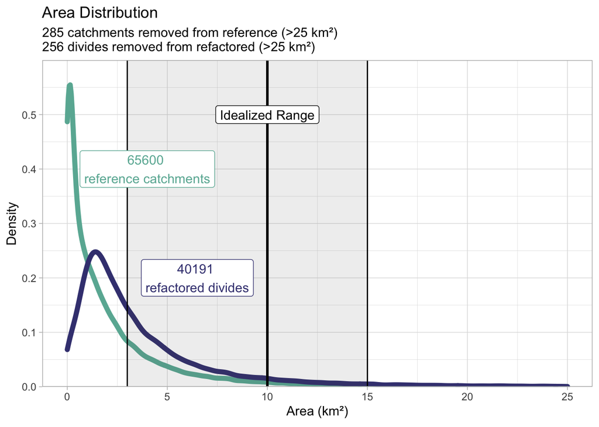

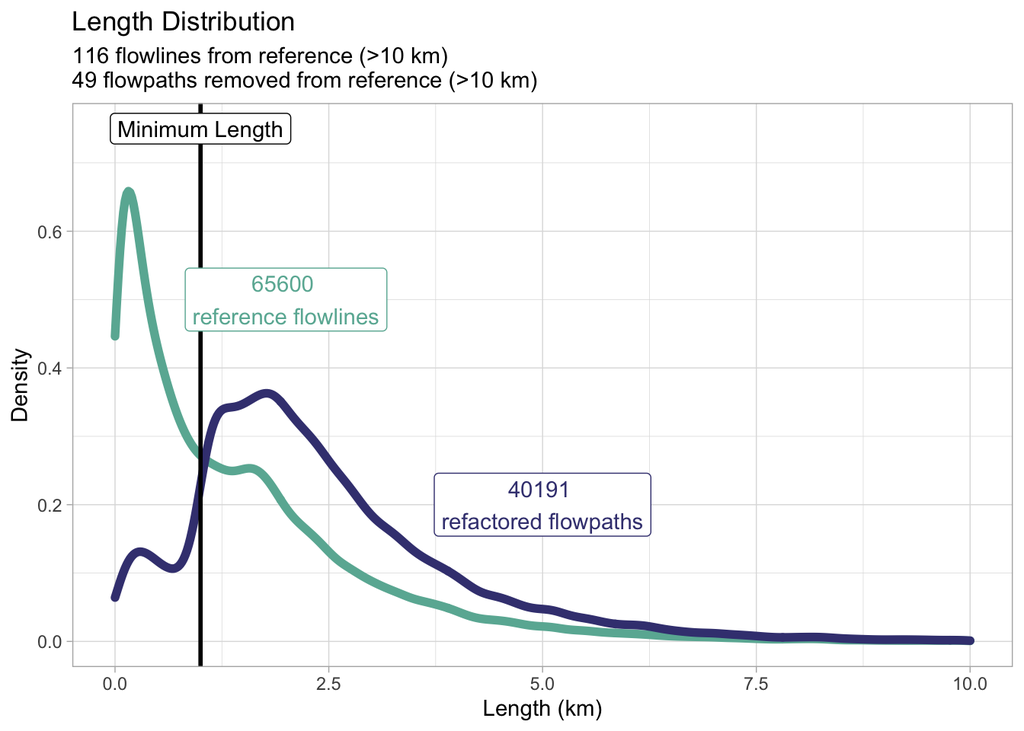

## Process

To overcome the mismatched scale in the reference/reference fabric and the Ngen modelling task, we need to aggregate the catchments to a defined user threshold/distribution. Therefore, nextgen is a **distribution based modeling task** that seeks to align the scale of process to scale of catchment representation.

`hyAggregate` allows users to prescribe an **ideal catchment size**, a **minimum catchment area**, and a **minimum flowpath length**. The default parameters used for Nextgen are an ideal catchment size of 10 km², a minimum catchment size of 3 km², and a minimum flowpath length of 1 km. A `refactored_fabric` can be aggregated to this distribution using `hyAggregate`:

```r
ngen_v1 =  aggregate_network_to_distribution(get_reference_fabric(VPU = VPU, dir = "data"),
                             outfile = glue("data/01_ngen_{VPU}.gpkg"),
                             nexus_topology = FALSE)
st_layers(ngen_v1)
```

```
#> Driver: GPKG
#> Available layers:
#>             layer_name geometry_type features fields
#> 1  aggregate_flowpaths                  17695     10
#> 2 aggregate_catchments                  17695      2
```

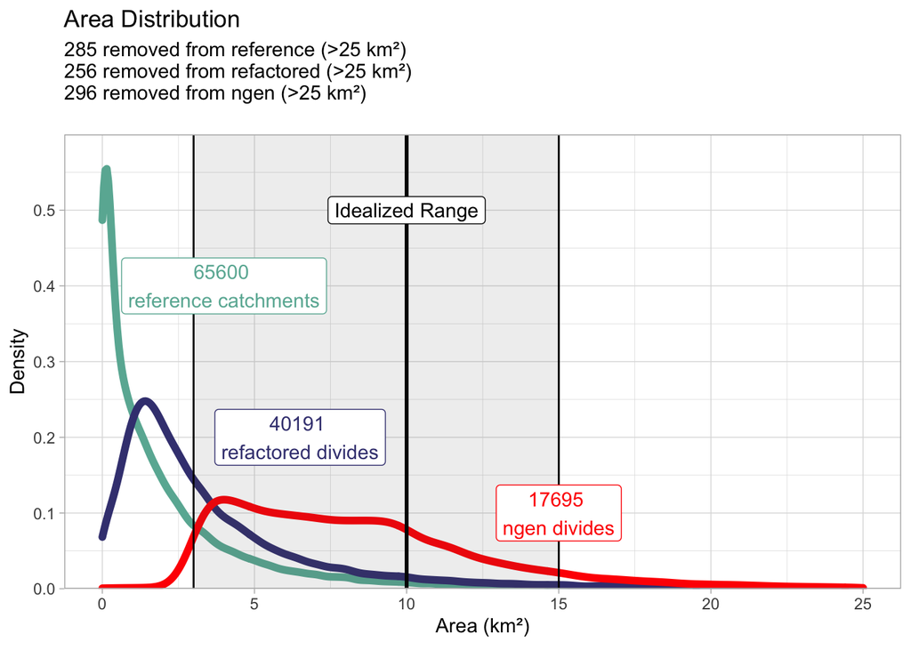

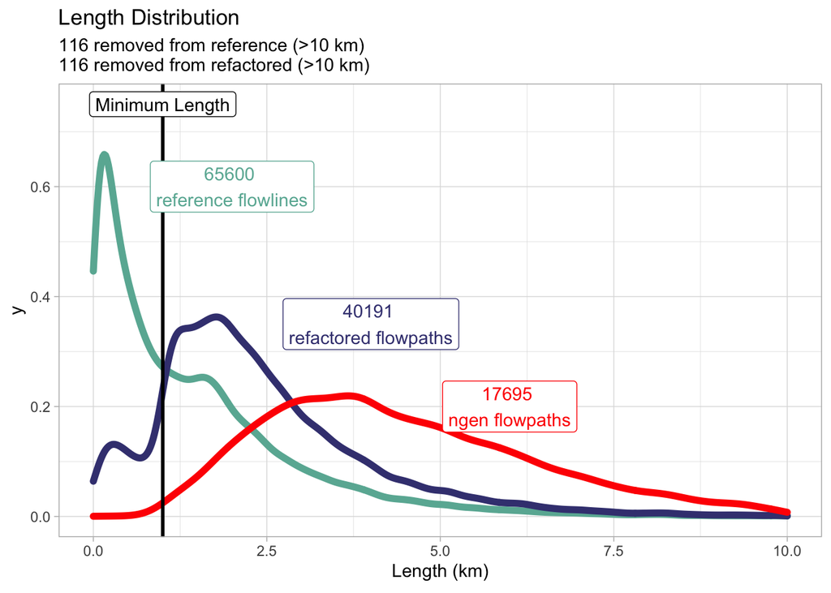

## Topology

To date, the NHDPlus topology (and many other flow network models) rely on flowpath-to-flowpath connectivity that describes the network in terms of how flowpaths connect to other flowpaths (therefore, which divides connect to other divides). The reference *and* refactored products retain this ‘flowline-to-flowline’ connectivity as does the ngen_aggregation when `nexus_topology=FALSE`.

```r
topology = read_sf(ngen_v1, 'aggregate_flowpaths') |>
  st_drop_geometry() |>
  select(id, toid)

head(topology)
```

```
#> # A tibble: 6 × 2
#>      id  toid
#>   <int> <dbl>
#> 1 25937 25928
#> 2 25928 25916
#> 3 25919 25918
#> 4 25939 25918
#> 5 25932 25918
#> 6 25918 25917
```

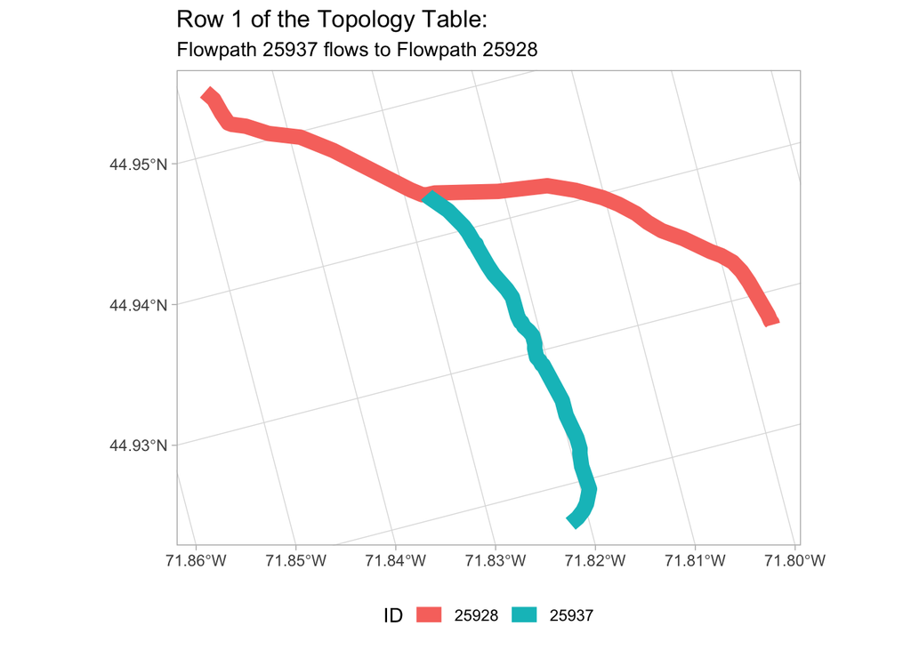

**Nextgen** is moving away from ‘flowline-to-flowline’ model towards ‘area-to-point’ model. Here the idea of ‘area’ is wrapped up into the holistic idea of a Hy_feature catchment and ‘point’ is captured by the conceptual idea of a hydro nexus.

**[hydro(-logic) Cathchment](https://docs.opengeospatial.org/is/14-111r6/14-111r6.html#_catchment):**

A physiographic unit where hydrologic processes take place. This class denotes a physiographic unit, which is defined by a hydrologically determined outlet to which all waters flow. While a catchment exists, it may or may not be clearly identified for repeated study. This approach considers the catchment concept to be the basic unit of study in hydrology, water resources management, and environmental reporting. The approach is meant to be holistic, referring to the continuous interaction of surface and subsurface waters within a catchment, even if a particular representation of the catchment refers to only surface or subsurface aspects of the catchment.

**[hydro(-logic) nexus](https://docs.opengeospatial.org/is/14-111r6/14-111r6.html#_hydro_logic_nexus):**

Conceptual outlet for water contained by a catchment. The hydro nexus concept represents the place where a catchment interacts with another catchment. Every catchment flows to a hydro nexus, conversely every location in a hydrologic system can be thought of as a hydro nexus that drains some catchment. Similar to catchments, hydro nexuses can be realized in several hydrology-specific ways.

If a given hydro nexus does not have a known hydrology-specific realization or is undetermined, it is termed ‘nillable’ in this standard. For example, a hydro nexus exists in the form of flow to the subsurface or atmosphere but may be undetermined and unrepresented within implementations focused on surface water hydrology and would not be included or referenced.

The long term advantage of this approach is the ability to use multi-scale networks, leverage community efforts in hydrologic addressing and representation, and to have a more defined computational element for Nextgen comparability.

In practice, this yields a scenario like below, where catchments may not flow to the coincident catchment but sometimes to the *downstream* nexus. This is highlighted where ‘cat-4’ not longer flows to ‘cat-3’ but instead to ‘nex-2’. At the same time, ‘cat-3’ is *also* flowing to ‘nex-2’ suggesting two areas (holistic cathcments) are flowing to one point (a hydro nexus).

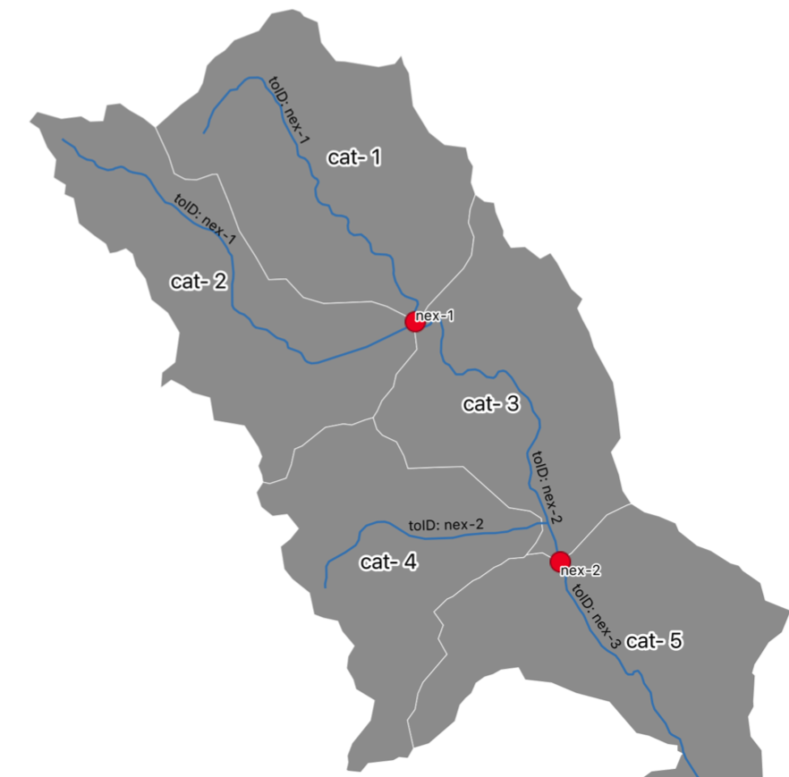

To generate the ‘nexus_topology’ (opposed to flowline) we can set the `nexus_topology=TRUE` and rerun the aggregation code.

```r
ngen_v2 = aggregate_network_to_distribution(
        gf = get_reference_fabric(VPU = VPU, dir = "data"),
        outfile        = glue("data/02_ngen_{VPU}.gpkg"),
        nexus_topology = TRUE)
st_layers(ngen_v2)
```

```
#> Driver: GPKG
#> Available layers:
#>             layer_name     geometry_type features fields
#> 1  aggregate_flowpaths Multi Line String    17695      9
#> 2 aggregate_catchments                      17695      3
#> 3                nexus             Point     8128      2
#> 4   flowpath_edge_list                NA    25827      2
```

Well see that this option produces a non-spatial “flowpath_edge_list” within the geopackage. Opening this table highlights the area to point topology where the area (holistic catchment) is *realized* as the waterbody (‘wb-’) of the flowpath.

```r
head(read_sf(ngen_v2, 'flowpath_edge_list'))
```

```
#> # A tibble: 6 × 2
#>   id       toid
#>   <chr>    <chr>
#> 1 wb-24715 nex-24403
#> 2 wb-17536 nex-17535
#> 3 wb-25914 tnex-1000000001
#> 4 wb-25776 tnex-1000000002
#> 5 wb-25745 tnex-1000000003
#> 6 wb-25737 tnex-1000000004
```

The choice to use the waterbody realization, is tied to the need for network topology to support hyrdologic and hydraulic routing.

## Routing Attributes

The core of the Nextgen modeling system uses t-route for hydrologic and hydraulic routing. `t-route` was designed to support the existing NWM and as such relies on routing parameters defined in the NWM Routelink file.

The `get_routelink_path()` function will search your `hyAggregate` R directory for a fst representation of the most current routelink file. If this file does not exist, then the code will

1. Check for the latest version of the nwm domain files on ncep. (2) Download the NetCDF (3) extract it into a [fst](https://www.fstpackage.org) file shown below:

```r
path = get_routelink_path()
fst::metadata_fst(path)
```

```
#> <fst file>
#> 2776738 rows, 20 columns (RouteLink_nwm_v2_1_6.fst)
#>
#> * 'comid'            : double
#> * 'NHDWaterbodyComID': double
#> * 'gages'            : character
#> * 'from'             : double
#> * 'to'               : double
#> * 'alt'              : double
#> * 'order'            : double
#> * 'Qi'               : double
#> * 'MusK'             : double
#> * 'MusX'             : double
#> * 'Length'           : double
#> * 'n'                : double
#> * 'So'               : double
#> * 'ChSlp'            : double
#> * 'BtmWdth'          : double
#> * 'time'             : double
#> * 'Kchan'            : double
#> * 'nCC'              : double
#> * 'TopWdthCC'        : double
#> * 'TopWdth'          : double
```

By specifying a `routelink_path`, `aggregate_network_to_distribution` knows to develop length-averaged routelink parameter and associations (gages and NHDWaterbodies). The length averaging is done by determining the proportion of each *reference* flowline (COMID) that falls within each aggregated catchment. The associated values are then weighted by the relative length:

```r
ngen_v3 =  aggregate_network_to_distribution(
        get_reference_fabric(VPU = VPU, dir = "data"),
        outfile        = glue("data/03_ngen_{VPU}.gpkg"),
        nexus_topology = TRUE,
        routelink_path = get_routelink_path())
st_layers(ngen_v3)
```

```
#> Driver: GPKG
#> Available layers:
#>             layer_name     geometry_type features fields
#> 1  aggregate_flowpaths Multi Line String    17695      9
#> 2 aggregate_catchments                      17695      3
#> 3                nexus             Point     8128      2
#> 4   flowpath_edge_list                NA    25827      2
#> 5  flowpath_attributes                NA    17695     16
```

```r
head(read_sf(ngen_v3, 'flowpath_attributes'))
```

```
#> # A tibble: 6 × 16
#>   id    gages NHDWaterbodyCom…    Qi  MusK  MusX       n       So  ChSlp BtmWdth
#>   <chr> <chr> <chr>            <dbl> <dbl> <dbl>   <dbl>    <dbl>  <dbl>   <dbl>
#> 1 wb-1  <NA>  <NA>                NA    NA  NA   NA      NA       NA       NA
#> 2 wb-10 <NA>  <NA>                 0  3600   0.2  0.05    1.28e-5  0.178   42.8
#> 3 wb-1… <NA>  <NA>                 0  3600   0.2  0.0503  4.53e-4  0.245   20.6
#> 4 wb-1… <NA>  <NA>                 0  3600   0.2  0.06    1.86e-2  0.494    4.20
#> 5 wb-1… <NA>  <NA>                 0  3600   0.2  0.06    8.38e-2  0.600    2.71
#> 6 wb-1… <NA>  <NA>                 0  3600   0.2  0.06    7.61e-2  0.577    2.97
#> # … with 6 more variables: time <dbl>, Kchan <dbl>, nCC <dbl>, TopWdthCC <dbl>,
#> #   TopWdth <dbl>, length_m <dbl>
```

## Hydrologic Model Attributes

While routing parameters and topologies are critical for modeling the flow of water, `runoff` formulations are critcal for simulating how much water will be in the channel.

The capacity for Ngen to encapsulate the idea of a catchment and implement a suite of different model formulations requires that critical attribute information is available to inform the wide range of models.

Since ngen runs runoff models at the catchment scale, and not at the gridded scale (at least as of now), there is a need to summarize gridded information to the catchment scale in a fast, flexable, and performant way.

This requires the ability to identify the quickly and accurately summarizes raster values over polygonal areas including paritially covered grid cells. Once the divide/raster cell relationships are established, we must define the way in which those values are summarized (collapsed). For example, do we want the “max tempeture per catchment” or the “mean temperture be catchment”?

For the initial Ngen modules (cfe and NOAH-OWP-modular) the following variables from the NWM gridded data are summarized using the following functions:

| Tables | Description | Layer(s) | Summary Function |
| --- | --- | --- | --- |
| bexp | Beta Parameter | 4 | mode |
| IVGTYP | Dominant category | 1 | mode |
| ISLTYP | Dominant category | 1 | mode |
| dksat | Saturated Soil Connectivity | 4 | geometric mean |
| psisat | Saturated soil matric potential | 4 | geometric mean |
| slope | Slope Index | 1 | mean |
| smcmax | Saturated value of soil moisture [volumetric] | 4 | mean |
| smcwlt | Wilting point soil moisture [volumetric] | 4 | mean |
| refkdt | Parameter in the surface runoff parameterization | 1 | mean |
| cwpvt | Empirical canopy wind parameter | 1 | mean |
| vcmx25 | Maximum rate of carboxylation at 25 C [ umol CO2/m2/s] | 1 | mean |
| mp | Slope of Conductance to photosynthesis relationship | 1 | mean |
| mfsno | Snowmelt m parameter | 1 | mean |
| Coef | Coefficient | 1 | mean |
| Zmax | Zmax | 1 | mean |
| Expon | Exponenet | 1 | mode |

For convinence, these layers have been combined and stored as a single NetCDF on [ScienceBase](https://www.sciencebase.gov/catalog/item/629a4246d34ec53d276f446d). The get `get_nwm_grids` function in hyAggregate will either return a file.path if it exists is the provided directory; download the cached file from ScienceBase (if cache_download = TRUE); or, build it from the files available on NCEP.

This summarization is wrapped in the function `aggregate_cfe_noahowp`, but can be reworked using `zonal` if more variables, or different summary functions are desired:

```r
ngen_v4 = glue("data/04_ngen_{VPU}.gpkg")
#file.copy(ngen_v3, ngen_v4)
```

```r
ngen_v4 = aggregate_cfe_noahowp(gpkg = ngen_v4, dir = 'data', add_to_gpkg = TRUE)
```

```r
st_layers(ngen_v4)
```

```
#> Driver: GPKG
#> Available layers:
#>               layer_name     geometry_type features fields
#> 1    aggregate_flowpaths Multi Line String    17695      9
#> 2   aggregate_catchments                      17695      3
#> 3                  nexus             Point     8128      2
#> 4     flowpath_edge_list                NA    25827      2
#> 5    flowpath_attributes                NA    17695     16
#> 6 cfe_noahowp_attributes                NA    17695     32
```

```r
glimpse(read_sf(ngen_v4, 'cfe_noahowp_attributes'))
```

```
#> Rows: 17,695
#> Columns: 32
#> $ id                          <chr> "cat-10", "cat-100", "cat-10000", "cat-100…
#> $ gw_Coeff                    <dbl> 0.005, 0.005, 0.005, 0.005, 0.005, 0.005, …
#> $ gw_Zmax                     <dbl> 21.81905, 61.28427, 189.44409, 189.44409, …
#> $ gw_Expon                    <dbl> 7, 4, 7, 7, 7, 7, 7, 7, 7, 7, 5, 5, 5, 5, …
#> $ ISLTYP                      <int> 6, 4, 3, 3, 3, 3, 3, 3, 3, 3, 3, 3, 2, 3, …
#> $ IVGTYP                      <int> 5, 15, 11, 11, 11, 11, 11, 11, 14, 14, 11,…
#> $ `bexp_soil_layers_stag=1`   <dbl> 8.182727, 8.145459, 5.627148, 5.627148, 5.…
#> $ `bexp_soil_layers_stag=2`   <dbl> 8.182727, 8.145459, 5.627148, 5.627148, 5.…
#> $ `bexp_soil_layers_stag=3`   <dbl> 8.182727, 8.145459, 5.627148, 5.627148, 5.…
#> $ `bexp_soil_layers_stag=4`   <dbl> 8.182727, 8.145459, 5.627148, 5.627148, 5.…
#> $ `dksat_soil_layers_stag=1`  <dbl> 9.674763e-06, 6.814276e-05, 2.274828e-05, …
#> $ `dksat_soil_layers_stag=2`  <dbl> 9.674763e-06, 6.814276e-05, 2.274828e-05, …
#> $ `dksat_soil_layers_stag=3`  <dbl> 9.674763e-06, 6.814276e-05, 2.274828e-05, …
```

[output cut: 19 more lines]

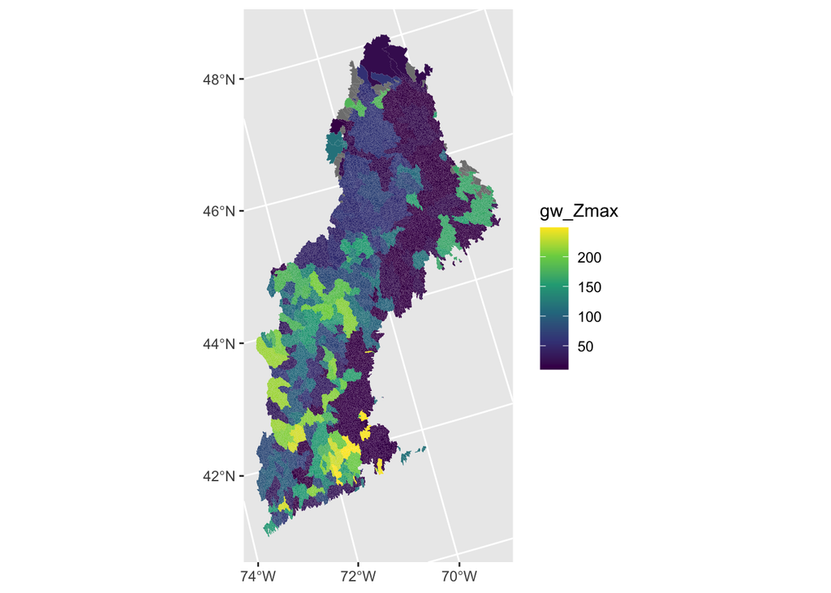

```r
tmp = left_join(read_sf(ngen_v4, "aggregate_catchments"), read_sf(ngen_v4, "cfe_noahowp_attributes"), by  = "id")

ggplot() +
  geom_sf(data = tmp, aes(fill = gw_Zmax), color = NA) +
  scale_fill_viridis_c()
```

## Read a File

It is worth highlighting that the geopackage is a critical file format for sharing this type of data because it is (1) self containing (2) compact and (3) language agnostic.

There are two broad paths to accessing the data. The first is a GDAL based approach (in R this is using sf, but in python finona or geopandas works well).

```r
# Read Options
pacman::p_load(sf, DBI, RSQLite, dplyr)

### 1. GDAL/geopackage
st_layers(ngen_v4)
```

```
#> Driver: GPKG
#> Available layers:
#>               layer_name     geometry_type features fields
#> 1    aggregate_flowpaths Multi Line String    17695      9
#> 2   aggregate_catchments                      17695      3
#> 3                  nexus             Point     8128      2
#> 4     flowpath_edge_list                NA    25827      2
#> 5    flowpath_attributes                NA    17695     16
#> 6 cfe_noahowp_attributes                NA    17695     32
```

```r
nex = read_sf(ngen_v4, "nexus")
head(nex)
```

```
#> Simple feature collection with 6 features and 2 fields
#> Geometry type: POINT
#> Dimension:     XY
#> Bounding box:  xmin: 1977397 ymin: 2906044 xmax: 2084058 ymax: 2983234
#> Projected CRS: NAD83 / Conus Albers
#> # A tibble: 6 × 3
#>   id      toid                 geom
#>   <chr>   <chr>         <POINT [m]>
#> 1 nex-175 cat-175 (2040728 2933224)
#> 2 nex-333 cat-333 (1977397 2906044)
#> 3 nex-358 cat-358 (2063599 2983234)
#> 4 nex-366 cat-366 (1992103 2962212)
#> 5 nex-385 cat-385 (2024950 2917374)
#> 6 nex-407 cat-407 (2084058 2966035)
```

The second is as a SQLite database (in R, I am doing this with RSQLite/DBI/dplyr):

```r
### 2. SQLite/Database
db <- dbConnect(SQLite(), ngen_v4)
dbListTables(db)
```

```
#>  [1] "aggregate_catchments"
#>  [2] "aggregate_flowpaths"
#>  [3] "cfe_noahowp_attributes"
#>  [4] "flowpath_attributes"
#>  [5] "flowpath_edge_list"
#>  [6] "gpkg_contents"
#>  [7] "gpkg_extensions"
#>  [8] "gpkg_geometry_columns"
#>  [9] "gpkg_ogr_contents"
#> [10] "gpkg_spatial_ref_sys"
#> [11] "gpkg_tile_matrix"
#> [12] "gpkg_tile_matrix_set"
#> [13] "nexus"
#> [14] "rtree_aggregate_catchments_geom"
#> [15] "rtree_aggregate_catchments_geom_node"
#> [16] "rtree_aggregate_catchments_geom_parent"
#> [17] "rtree_aggregate_catchments_geom_rowid"
#> [18] "rtree_aggregate_flowpaths_geom"
#> [19] "rtree_aggregate_flowpaths_geom_node"
#> [20] "rtree_aggregate_flowpaths_geom_parent"
#> [21] "rtree_aggregate_flowpaths_geom_rowid"
#> [22] "rtree_nexus_geom"
#> [23] "rtree_nexus_geom_node"
#> [24] "rtree_nexus_geom_parent"
#> [25] "rtree_nexus_geom_rowid"
#> [26] "sqlite_sequence"
```

```r
fpa = collect(tbl(db, "flowpath_attributes"))

head(fpa)
```

```
#> # A tibble: 6 × 17
#>     fid id      gages NHDWaterbodyCom…    Qi  MusK  MusX       n       So  ChSlp
#>   <int> <chr>   <chr> <chr>            <dbl> <dbl> <dbl>   <dbl>    <dbl>  <dbl>
#> 1     1 wb-1    <NA>  <NA>                NA    NA  NA   NA      NA       NA
#> 2     2 wb-10   <NA>  <NA>                 0  3600   0.2  0.05    1.28e-5  0.178
#> 3     3 wb-100  <NA>  <NA>                 0  3600   0.2  0.0503  4.53e-4  0.245
#> 4     4 wb-100… <NA>  <NA>                 0  3600   0.2  0.06    1.86e-2  0.494
#> 5     5 wb-100… <NA>  <NA>                 0  3600   0.2  0.06    8.38e-2  0.600
#> 6     6 wb-100… <NA>  <NA>                 0  3600   0.2  0.06    7.61e-2  0.577
#> # … with 7 more variables: BtmWdth <dbl>, time <dbl>, Kchan <dbl>, nCC <dbl>,
#> #   TopWdthCC <dbl>, TopWdth <dbl>, length_m <dbl>
```

```r
dbDisconnect(db)
```

## Writing Nextgen Output

The geopackage serves as a consise, interoperaple and efficient format for distributing packaged data that is tabular and spatial. However it does not meet everyones need. In particular ngen operates using JSON/geoJSON files. Simulalry the ESRI family of toosl (e.g. ArcMap/ArcPro/ArcGIS Online) *cannot* read geopackges.

As such, we offer a final function that generated the ngen files, and optionally shapefiles, from a GPKG.

```r
write_ngen_dir(ngen_v4, export_shapefiles = TRUE)
```

This function creates a directory at the same level and named as the GPKG and outputs the following files:

```r
fs::dir_tree(glue("data/04_ngen_{VPU}"))
```

```
#> data/04_ngen_01
#> ├── catchment_data.geojson
#> ├── crosswalk-mapping.json
#> ├── flowpath_edge_list.json
#> ├── flowpath_params.json
#> ├── nexus_data.geojson
#> └── shps
#>     ├── aggregate_catchments.dbf
#>     ├── aggregate_catchments.prj
#>     ├── aggregate_catchments.shp
#>     ├── aggregate_catchments.shx
#>     ├── aggregate_flowpaths.dbf
#>     ├── aggregate_flowpaths.prj
#>     ├── aggregate_flowpaths.shp
#>     ├── aggregate_flowpaths.shx
#>     ├── cfe_noahowp_attributes.dbf
#>     ├── flowpath_attributes.dbf
#>     ├── flowpath_edge_list.dbf
#>     ├── nexus.dbf
#>     ├── nexus.prj
#>     ├── nexus.shp
#>     └── nexus.shx
```

## Cross-walk

If you have made it this far - thanks! A small detail you might notice is that in the data/ngen_01 dirctory created from the GPKG, there is a new file called `crosswalk-mapping.json`

```r
library(jsonlite)
```

```r
cw = fromJSON('data/04_ngen_01/crosswalk-mapping.json')

# File with gage!
cw$`wb-16354`
```

```
#> $member_comids
#> [1] 7698892 7699072 6782191
#>
#> $gages
#> [1] "01172010"
#>
#> $outlet_comid
#> [1] 7698892
#>
#> $main_id
#> [1] 25002
```

```r
# Feature w/o gage
cw$`wb-22117`
```

```
#> $member_comids
#> [1] 5860417
#>
#> $outlet_comid
#> [1] 5860417
#>
#> $main_id
#> [1] 33927
```

## Network Tracing

So the last step here is a non-function-ized way to use these files in conjunction to subset the network based on the flowpaths that flow to a USGS gage.

In the above code chunk, we saw that `wb-16354` was associated with `NWIS:01172010`. To find the network upstream of that gage, we can use the topology (edge list) and the determined identifier to ‘sort’ the netowrk. The returned results is a sorted set if IDs upstream of the porvided outlet. These IDs can then be used to extract the flowpath or divide network.

```r
library(nhdplusTools)
system.time({
  trace = get_sorted(read_sf(ngen_v4, 'flowpath_edge_list'),
                     split = TRUE,
                     outlets = 'wb-16354')

  flowpaths = filter(read_sf(ngen_v4,  'aggregate_flowpaths'), id %in% trace$id)
})
```

```
#>    user  system elapsed
#>   0.436   0.060   0.606
```

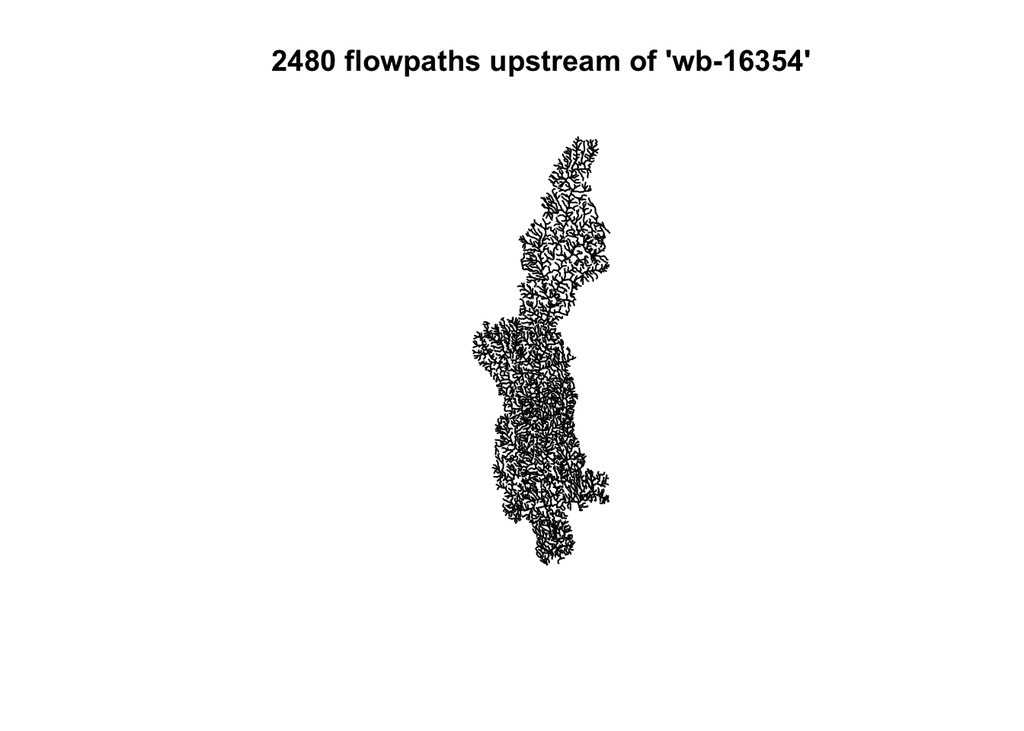

```r
plot(st_geometry(flowpaths), main = paste(nrow(flowpaths), "flowpaths upstream of 'wb-16354'"))
```

[^1]: Lynker, jjohnson@lynker.com
[^2]: Blodgett, D., Johnson, J.M., 2022, hyRefactor: Tools for Manipulating the NHDPlus Network in Preparation for Hydrologic Modeling